# 16.1: Smart Drug

## Introduction

This is the example from Section 16.1 of Kruschke on the (fictitious) effect of the “smart drug”. Make sure the “TwoGroupIQ.csv” file is in your project directory.

## Preliminaries

Load necessary packages:

```r
library(tidyverse)
library(rstan)
library(shinystan)
```

Set Stan to save compiled code.

```r
rstan_options(auto_write = TRUE)
```

Set Stan to use parallel processing where possible.

```r
options(mc.cores = parallel::detectCores())
```

## Data

```r
IQ_data <- read_csv("TwoGroupIQ.csv")
IQ_data
```

| Score | Group |
| --- | --- |
| 102 | Smart Drug |
| 107 | Smart Drug |
| 92 | Smart Drug |
| 101 | Smart Drug |
| 110 | Smart Drug |
| 68 | Smart Drug |
| 119 | Smart Drug |
| 106 | Smart Drug |
| 99 | Smart Drug |
| 103 | Smart Drug |

[output cut: 110 more lines]

For this 1-sample test, we will only look at those who took the smart drug.

```r
IQ1_data <- IQ_data %>%
    filter(Group == "Smart Drug")
IQ1_data
```

| Score | Group |
| --- | --- |
| 102 | Smart Drug |
| 107 | Smart Drug |
| 92 | Smart Drug |
| 101 | Smart Drug |
| 110 | Smart Drug |
| 68 | Smart Drug |
| 119 | Smart Drug |
| 106 | Smart Drug |
| 99 | Smart Drug |
| 103 | Smart Drug |

[output cut: 53 more lines]

```r
N <- NROW(IQ1_data)
y <- IQ1_data$Score
stan_data <- list(N = N, y = y)
```

## Stan code

```stan
data {
    int<lower = 0> N;
    real<lower = 0> y[N];
}
transformed data {
    real<lower = 0> M;
    real<lower = 0> S;
    real<lower = 0> L;
    real<lower = 0> H;

    M = 100;
    S = 100;
    L = 0;
    H = 1000;
}
parameters {
    real<lower = 0> mu;
    real<lower = 0> sigma;
}
model {
    mu ~ normal(M, S);
    sigma ~ uniform(L, H);
    y ~ normal(mu, sigma);
}
generated quantities {
    real y_rep[N];

    for (n in 1:N) {
        y_rep[n] = normal_rng(mu, sigma);
    }
}
```

## Sampling from the model

```r
set.seed(11111)
```

[output not shown]

```r
fit_IQ <- sampling(IQ, data = stan_data, refresh = 0)
```

## Diagnosing the model

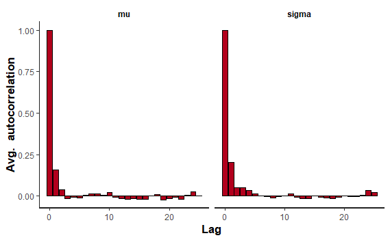

```r
plot(fit_IQ, plotfun = "ac", pars = c("mu", "sigma"))
```

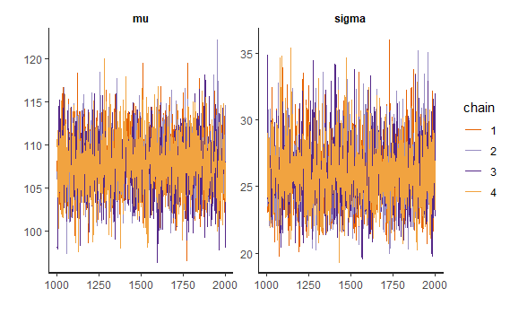

```r
plot(fit_IQ, plotfun = "trace",
     pars = c("mu", "sigma"))
```

## Summarizing the model

```r
print(fit_IQ, pars = c("mu", "sigma"))
```

```
Inference for Stan model: stan-26901cbc4f1f.
4 chains, each with iter=2000; warmup=1000; thin=1;
post-warmup draws per chain=1000, total post-warmup draws=4000.

        mean se_mean   sd   2.5%    25%    50%    75%  97.5% n_eff
mu    107.79    0.06 3.35 101.37 105.57 107.77 109.97 114.49  2797
sigma  26.03    0.05 2.42  21.86  24.37  25.86  27.47  31.39  2355
      Rhat
mu       1
sigma    1

Samples were drawn using NUTS(diag_e) at Wed May 29 21:28:36 2019.
For each parameter, n_eff is a crude measure of effective sample size,
and Rhat is the potential scale reduction factor on split chains (at
convergence, Rhat=1).
```

## Visualizing the model

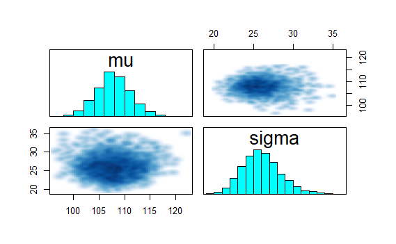

```r
pairs(fit_IQ, pars = c("mu", "sigma"))
```

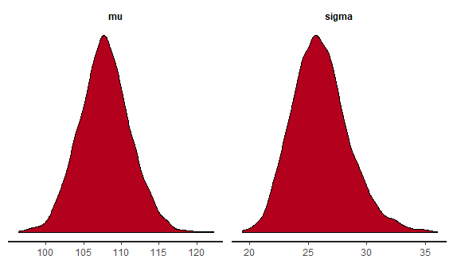

```r
plot(fit_IQ, plotfun = "dens", pars = c("mu", "sigma"))
```

```
ci_level: 0.8 (80% intervals)
outer_level: 0.95 (95% intervals)
```

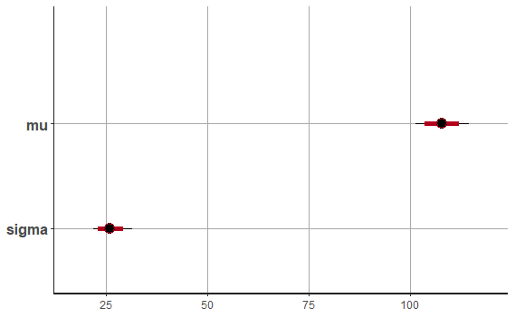

```r
plot(fit_IQ, pars = c("mu", "sigma"))
```

## Examining the prior

```stan
data {
    int<lower = 0> N;
    real<lower = 0> y[N];
}
transformed data {
    real<lower = 0> M;
    real<lower = 0> S;
    real<lower = 0> L;
    real<lower = 0> H;

    M = 100;
    S = 100;
    L = 0;
    H = 1000;
}
parameters {
    real<lower = 0> mu;
    real<lower = 0> sigma;
}
model {
    mu ~ normal(M, S);
    sigma ~ uniform(L, H);
//    y ~ normal(mu, sigma);
}
```

```r
set.seed(11111)
fit_IQ_prior <- sampling(IQ_prior, data = stan_data, refresh = 0)
```

```
There were 2905 divergent transitions after warmup. Increasing adapt_delta above 0.8 may help. See
http://mc-stan.org/misc/warnings.html#divergent-transitions-after-warmupExamine the pairs() plot to diagnose sampling problems
```

```r
fit_IQ_prior
```

```
Inference for Stan model: stan-20cc2ce96b3c.
4 chains, each with iter=2000; warmup=1000; thin=1;
post-warmup draws per chain=1000, total post-warmup draws=4000.

        mean se_mean     sd  2.5%    25%    50%    75%  97.5% n_eff
mu    130.78    5.84  82.52  4.12  66.96 123.70 183.05 322.98   200
sigma 521.24   14.95 286.31 23.02 280.58 527.44 768.96 980.61   367
lp__   10.07    0.13   1.56  5.70   9.53  10.51  11.15  11.68   146
      Rhat
mu    1.03
sigma 1.00
lp__  1.02

Samples were drawn using NUTS(diag_e) at Tue May 28 17:34:53 2019.
For each parameter, n_eff is a crude measure of effective sample size,
and Rhat is the potential scale reduction factor on split chains (at
convergence, Rhat=1).
```

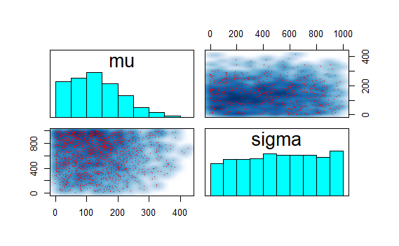

```r
pairs(fit_IQ_prior, pars = c("mu", "sigma"))
```

```
ci_level: 0.8 (80% intervals)
outer_level: 0.95 (95% intervals)
```

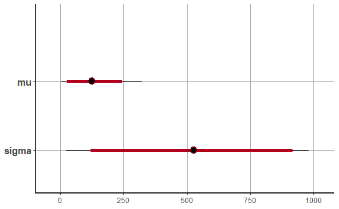

```r
plot(fit_IQ_prior, pars = c("mu", "sigma"))
```

## Posterior predictive check

Extract predicted values:

```r
samples_IQ <- extract(fit_IQ)
y_rep <- samples_IQ$y_rep
```

Graph values of $y$ against summaries of $y_{rep}$. There are lots of options for numerical data.

For the ones that generate lots of subgraphs, we’ll only compare the data to the first 5 replications.

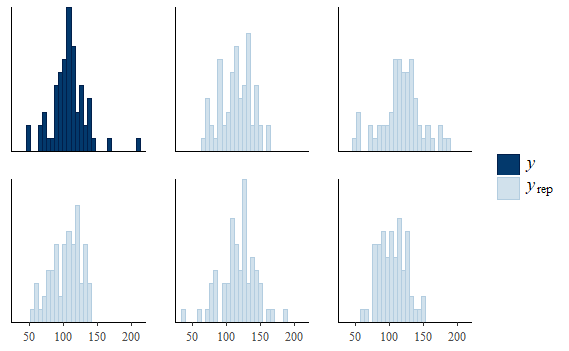

```r
ppc_hist(y, y_rep[1:5, ])
```

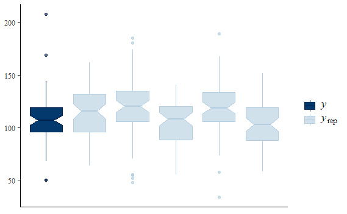

```r
ppc_boxplot(y, y_rep[1:5, ])
```

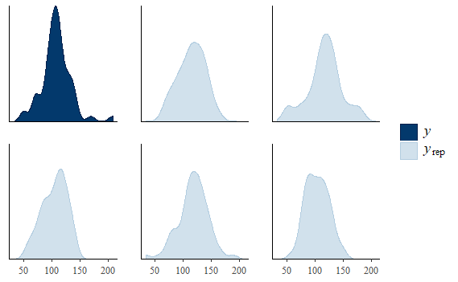

```r
ppc_dens(y, y_rep[1:5, ])
```

In an overlay, we can include a few more. (In theory, we could include all replications, but the function takes a long time to process.)

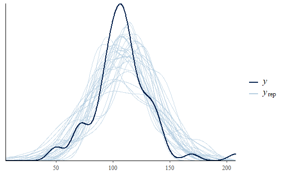

```r
ppc_dens_overlay(y, y_rep[1:30, ])
```

For test statistics, we can include all replications.

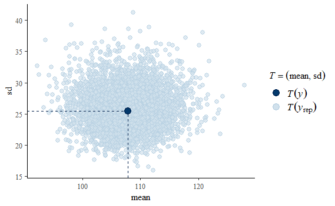

```r
ppc_stat_2d(y, y_rep)
```

Same goes for intervals. (This graph is getting a little on the busy side. For larger data sets, we would want to limit the number of replications in one plot.

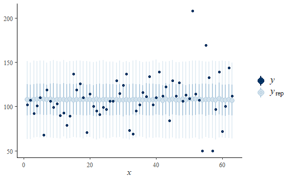

```r
ppc_intervals(y, y_rep)
```

## ShinyStan

Run the following code from the Console:

```
launch_shinystan(fit_IQ)
```